# Desafio Data Science

Antonio Prado

October 31, 2018

## Análise do dataset

#### Carregando dados:

```r
bank_data <- read.csv("bank-full.csv", sep = ";")
```

#### Verificando as dimensões dos dados:

```r
dim(bank_data)
```

```
## [1] 45211    17
```

Pelo número de entradas, 45211, podemos perceber que esse banco de dados está relacionado com os dados após a terceira iteração do método CRISP-DM realizada no artigo “USING DATA MINING FOR BANK DIRECT MARKETING: AN APPLICATION OF THE CRISP-DM METHODOLOGY”, disponível em http://hdl.handle.net/1822/14838. Nesse dataset, como descrito no arquivo “bank-names.txt”, não há instâncias com atributos faltantes e alguns atributos foram suprimidos.

Vemos que o problema original é um problema de classificação com variáveis mistas, embora as questões específicas do desafio possam representar problemas diferentes.

## Preparação do ambiente

#### Instalando pacotes

Utilizamos a biblioteca caret para algumas tarefas básicas, bem como outras bibliotecas para treinamentos específicos:

```r
install.packages("caret")
install.packages("ggplot2")
install.packages("dplyr")
install.packages("stats")
```

#### Carregando bibliotecas

```r
library(caret)
library(ggplot2)
library(dplyr)
library(stats)
```

## Questões

#### 1. Qual profissão tem mais tendência a fazer um empréstimo? De qual tipo?

Pelo dataset, encontramos dois tipos diferentes de empréstimos, listados como variáveis categóricas (cada cliente possui ou não possui tal tipo de empréstimo). O primeiro deles, “housing”, indica se o cliente possui empréstimo imobiliário, enquanto o segundo, “loan”, indica se o cliente possui empréstimo pessoal.

Contagem de clientes por tipo de trabalho:

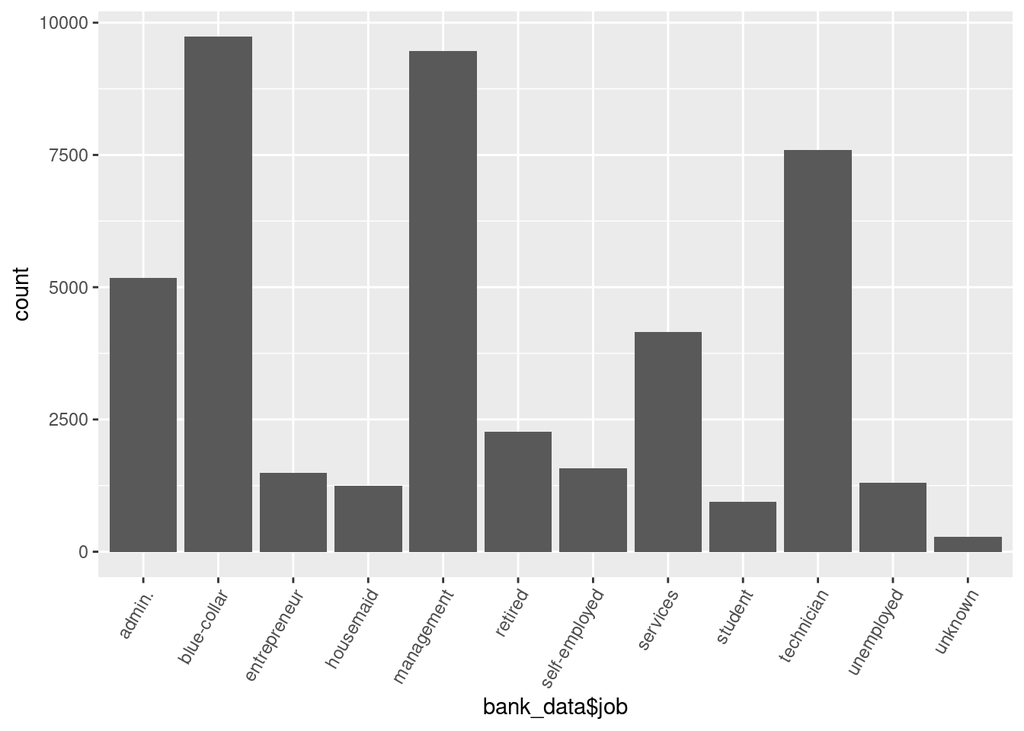

```r
ggplot(bank_data, aes(x=bank_data$job )) + geom_bar() +
    theme(axis.text.x = element_text(angle = 60, hjust = 1))
```

```r
plyr::count(bank_data, "job")
```

```
##              job freq
## 1         admin. 5171
## 2    blue-collar 9732
## 3   entrepreneur 1487
## 4      housemaid 1240
## 5     management 9458
## 6        retired 2264
## 7  self-employed 1579
## 8       services 4154
## 9        student  938
## 10    technician 7597
## 11    unemployed 1303
## 12       unknown  288
```

Contagem de clientes que possuem algum tipo de empréstimo:

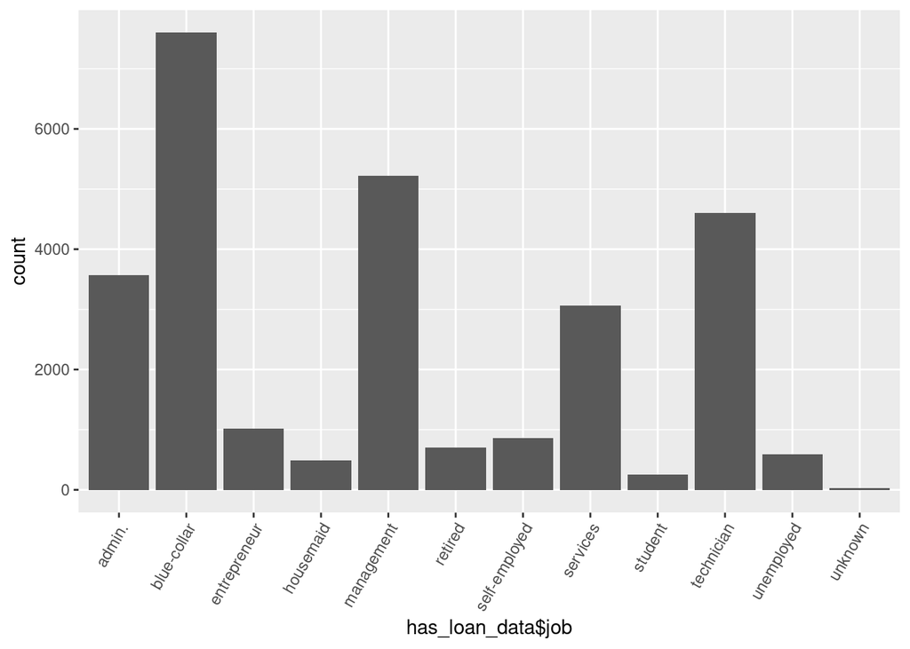

```r
has_loan_data  <- subset(bank_data, housing=="yes" | loan=="yes", select=c(job, housing, loan))
ggplot(has_loan_data, aes(x=has_loan_data$job )) + geom_bar() +
    theme(axis.text.x = element_text(angle = 60, hjust = 1))
```

```r
plyr::count(has_loan_data, "job")
```

```
##              job freq
## 1         admin. 3569
## 2    blue-collar 7599
## 3   entrepreneur 1016
## 4      housemaid  490
## 5     management 5225
## 6        retired  699
## 7  self-employed  864
## 8       services 3063
## 9        student  257
## 10    technician 4608
## 11    unemployed  589
## 12       unknown   28
```

Proporção de clientes que possuem algum tipo de empréstimo, para cada trabalho:

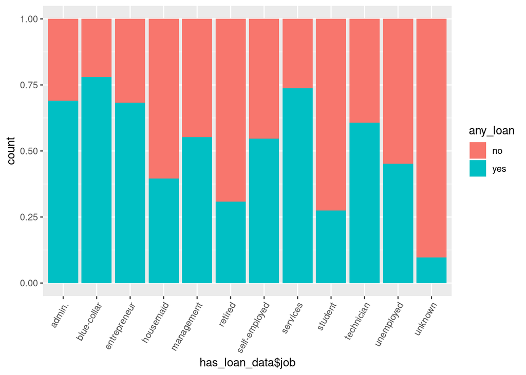

```r
has_loan_data <- mutate(bank_data, any_loan = ifelse(loan=="yes", "yes", ifelse(housing=="yes", "yes", "no")))
ggplot(has_loan_data, aes(x=has_loan_data$job, fill = any_loan)) +
    geom_bar(position = "fill") + theme(axis.text.x = element_text(angle = 60, hjust = 1))
```

Mais especificamente, para os trabalhadores com maior proporção de empréstimos, temos:

```r
bc_loan_proportion = sum(has_loan_data$any_loan=="yes" & has_loan_data$job=="blue-collar") /
    sum(has_loan_data$job=="blue-collar")
bc_loan_proportion
```

```
## [1] 0.7808261
```

Olhando para o tipo de empréstimos, temos:

```r
bc_loan_housing = sum(has_loan_data$housing=="yes" & has_loan_data$job=="blue-collar") /
    sum(has_loan_data$any_loan=="yes" & has_loan_data$job=="blue-collar")
bc_loan_housing
```

```
## [1] 0.9274905
```

```r
bc_loan_loan = sum(has_loan_data$loan=="yes" & has_loan_data$job=="blue-collar") /
    sum(has_loan_data$any_loan=="yes" & has_loan_data$job=="blue-collar")
bc_loan_loan
```

```
## [1] 0.2216081
```

Esses resultados nos mostram que, no espaço dos clientes do banco em questão, os chamados trabalhadores “blue-collar” são os que possuem maior tendência a possuírem empréstimos (78%), sendo que, dos que possuem algum empréstimo, aproximadamente 93% deles possuem um empréstimo imobiliário e 22% deles possuem um empréstimo pessoal.

#### 2. Fazendo uma relação entre número de contatos e sucesso da campanha quais são os pontos relevantes a serem observados?

Analisando os dados, considerando que o sucesso da campanha se refere à campanha atual, isto é, a variável y do dataset. Fazendo uma contagem preliminar da freqência absoluta do número de contatos, nessa campanha e em campanhas anteriores:

```r
contacts_data <- bank_data[, c(13, 15, 17)]
contacts_campaign <- plyr::count(contacts_data, "campaign")
contacts_previous <- plyr::count(contacts_data, "previous")
plyr::count(contacts_data, "campaign")
```

```
##    campaign  freq
## 1         1 17544
## 2         2 12505
## 3         3  5521
## 4         4  3522
## 5         5  1764
## 6         6  1291
## 7         7   735
## 8         8   540
## 9         9   327
## 10       10   266
## 11       11   201
## 12       12   155
## 13       13   133
## 14       14    93
```

[output cut: 34 more lines]

```r
plyr::count(contacts_data, "previous")
```

```
##    previous  freq
## 1         0 36954
## 2         1  2772
## 3         2  2106
## 4         3  1142
## 5         4   714
## 6         5   459
## 7         6   277
## 8         7   205
## 9         8   129
## 10        9    92
## 11       10    67
## 12       11    65
## 13       12    44
## 14       13    38
```

[output cut: 27 more lines]

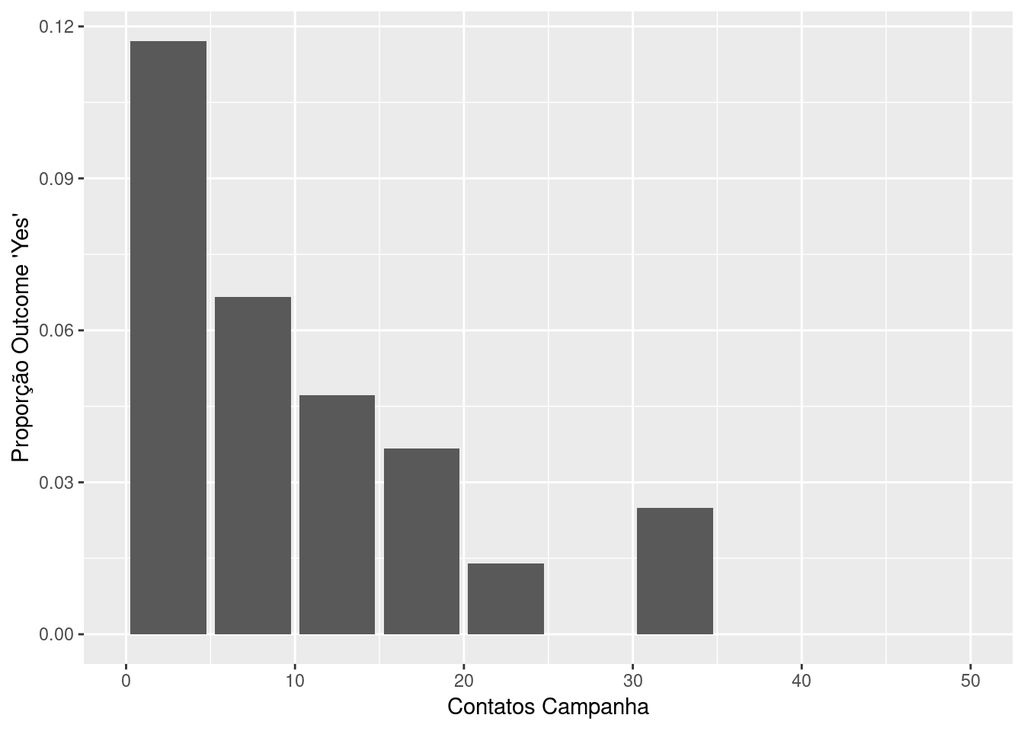

```r
range <- (1:10)
lista1 <- (1:10)
lista2 <- (1:10)
lista_campaign <- (1:10)
lista_previous <- (1:10)
for (x in range){
    lista1[x] <- sum(contacts_data$campaign==(5*x)-5 | contacts_data$campaign==(5*x)-4 | contacts_data$campaign==(5*x)-3 | contacts_data$campaign==(5*x)-2 | contacts_data$campaign==(5*x)-1)
    lista2[x] <- sum((contacts_data$campaign==(5*x)-5 | contacts_data$campaign==(5*x)-4 | contacts_data$campaign==(5*x)-3 | contacts_data$campaign==(5*x)-2 | contacts_data$campaign==(5*x)-2) & contacts_data$y=="yes")
    lista_campaign[x] <- lista2[x]/lista1[x]
}
for (x in range){
    lista1[x] <- sum((contacts_data$previous==(5*x)-5 | contacts_data$previous==(5*x)-4 | contacts_data$previous==(5*x)-3 | contacts_data$previous==(5*x)-2 | contacts_data$previous==(5*x)-1) & contacts_data$previous>=1)
    lista2[x] <- sum((contacts_data$previous==(5*x)-5 | contacts_data$previous==(5*x)-4 | contacts_data$previous==(5*x)-3 | contacts_data$previous==(5*x)-1 | contacts_data$previous==(5*x)-1) & contacts_data$y=="yes" & contacts_data$previous>=1)
    lista_previous[x] <- lista2[x]/lista1[x]
}

ggplot(data.frame(range),aes((range*5)-2.5,lista_campaign))+geom_bar(stat="identity") + xlim(0, 50) + labs(x = "Contatos Campanha", y = "Proporção Outcome 'Yes'")
```

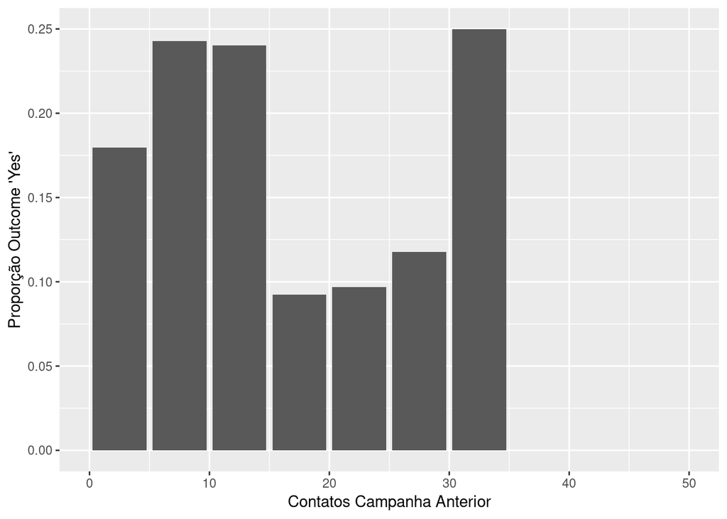

```r
ggplot(data.frame(range),aes((range*5)-2.5,lista_previous))+geom_bar(stat="identity") + xlim(0, 50) + labs(x = "Contatos Campanha Anterior", y = "Proporção Outcome 'Yes'")
```

Devido ao grande número de possíveis contatos, o que dificultava a análise, nos gráficos acima eles foram agrupados em compartimentos de tamanho cinco e calculada a proporção de sucesso de cada compartimento. No primeiro gráfico todos os clientes foram considerados. No segundo, apenas os que já haviam sido contatados anteriormente. Podemos ver que a porporção de sucessos da campanha atual cai com o aumento do número de contatos. O que não quer dizer que haja uma relação causal nesse sentido, um possível cliente mais indeciso potencialmente pode receber mais ligações, mesmo que sua probabilidade de assinar o plano fosse baixa desde o início. Para campanhas anteriores, o número de contatos não parece ter uma relação muito clara com o sucesso da campanha atual. Apesar disso, podemos perceber que a taxa de adesão da campanha atual, considerando os clientes que haviam sido contatados ateriormente, é significativamente maior (23%) que a taxa de adesão geral (11%):

```r
plyr::count(contacts_data$previous>=1)
```

```
##       x  freq
## 1 FALSE 36954
## 2  TRUE  8257
```

```r
plyr::count(contacts_data$previous>=1 & contacts_data$y=="yes")
```

```
##       x  freq
## 1 FALSE 43306
## 2  TRUE  1905
```

```r
1905 / 8257
```

```
## [1] 0.2307133
```

```r
plyr::count(contacts_data$campaign>=1)
```

```
##      x  freq
## 1 TRUE 45211
```

```r
plyr::count(contacts_data$campaign>=1 & contacts_data$y=="yes")
```

```
##       x  freq
## 1 FALSE 39922
## 2  TRUE  5289
```

```r
5289 / 45211
```

```
## [1] 0.1169848
```

#### 3. Baseando-se nos resultados de adesão desta campanha qual o número médio e o máximo de ligações que você indica para otimizar a adesão?

Considerando os gráficos da questão anterior, que exibiam a taxa de sucesso da campanha considerando todos os clientes e apenas os contactados anteriormente, pudemos perceber que em ambos os casos a taxa de sucesso caía bastante para clientes com número de contatos acima de 15, 20. Considerando também que campanhas com maior número de ligações tendem a ser mais caras, eu indicaria um máximo de 15 ligações, e uma média entre 5 e 10 ligações para cada cliente.

#### 4. O resultado da campanha anterior tem relevância na campanha atual?

Para determinar a relevância do resultado anterior podemos verificar se as duas variáveis são independentes. Isto é, se o conhecimento sobre o valor da variável “poutcome” modifica a probabilidade esperada do valor da variável “y”. Como ambas as variáveis são categóricas, podemos utilizar o teste qui-quadrado de Pearson, incluso na biblioteca stats. Nossa hipótese nula será de que as duas variáveis são independentes, e a nossa hipótese alternativa de que elas são dependentes entre si.

```r
chisq.test(bank_data$poutcome, bank_data$y)
```

```
##
##  Pearson's Chi-squared test
##
## data:  bank_data$poutcome and bank_data$y
## X-squared = 4391.5, df = 3, p-value < 2.2e-16
```

De acordo com a documentação do dataset, a variável “poutcome” pode assumir quatro valores: “unknown”,“other”,“failure”,“success”. Caso quiséssemos trabalhar com apenas dois valores possíveis, por exemplo, poderíamos agrupar “unknown”,“other” e “failure” em um único valor, deixando “success” para o restante, e aplicar o teste novamente:

```r
bank_outcome <- bank_data %>%
  mutate(poutcome2 = (poutcome=="success"))

chisq.test(bank_outcome$poutcome2, bank_outcome$y)
```

```
##
##  Pearson's Chi-squared test with Yates' continuity correction
##
## data:  bank_outcome$poutcome2 and bank_outcome$y
## X-squared = 4249.9, df = 1, p-value < 2.2e-16
```

O resultado de ambos os testes nos revelou um p-value consideravelmente baixo, de 2.2 * 10^(-16). A partir desse valor podemos com confiança rejeitar a hipótese nula em favor da hipótese alternativa, isto é, o resultado da campanha anterior tem relevância ao predizermos o resultado da campanha atual.

#### 5. Qual o fator determinante para que o banco exija um seguro de crédito?

Não sei se entendi muito bem essa pergunta… O dataset em questão se refere a se clientes realizarão depósitos a prazo no banco, então não vejo a necessidade de seguro de crédito por parte do banco. Caso a pergunta seja mais geral, acredito que as variáveis “loan”, “housing” e “default” possam ter relação com a necessidade de seguro. Dessas variáveis, “default” provavelmente seria a mais relevante, pois indica a inadimplência do cliente com relação a outros créditos.

#### 6. Quais são as características mais proeminentes de um cliente que possua empréstimo imobiliário?

Podemos separar o dataset em dois grupos, sendo um dele possuidor de crédito imobiliário e outro não possuidor, de forma a podermos extrair atributos dos dois grupos e compará-los.

```r
has_housing <- bank_data[ which(bank_data$housing=="yes"), ]
not_housing <- bank_data[ which(bank_data$housing=="no"), ]
```

O dataset original contém 8 atributos para os clientes. Removendo-se o atributo housing, que foi utilizado para a separação dos grupos, ficamos com: age (numérico), job (categórico), marital (categórico), education (categórico), default (categórico), balance (numérico) e loan (categórico). Podemos verificar individualmente cada um deles, em busca de anomalias.

Primeiro os atributos numéricos:

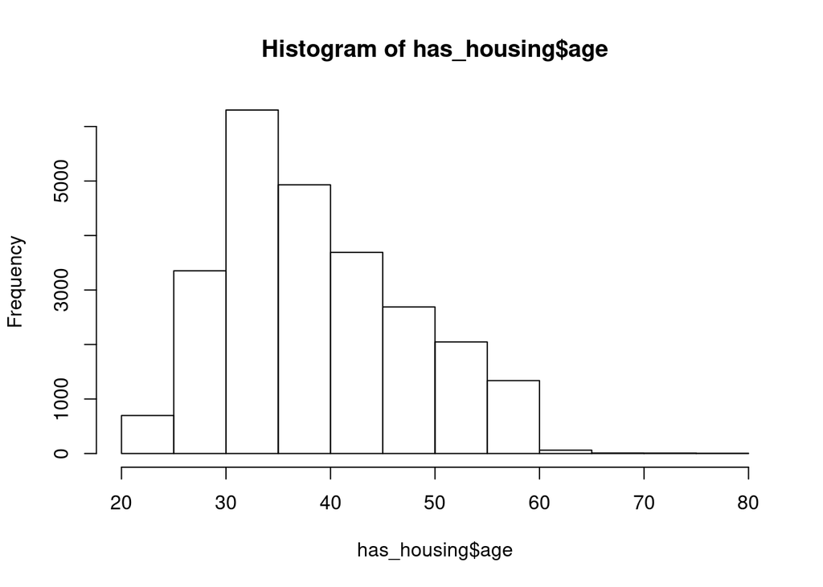

```r
hist(has_housing$age)
```

```r
mean(has_housing$age)
```

```
## [1] 39.17529
```

```r
median(has_housing$age)
```

```
## [1] 38
```

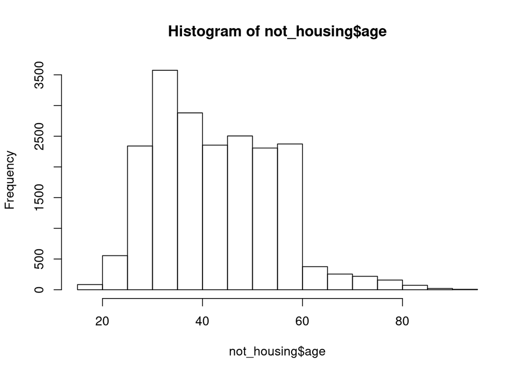

```r
hist(not_housing$age)
```

```r
mean(not_housing$age)
```

```
## [1] 43.13988
```

```r
median(not_housing$age)
```

```
## [1] 42
```

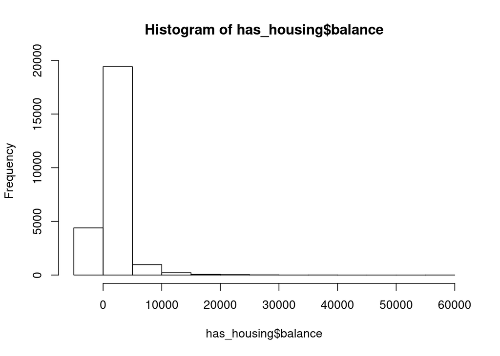

```r
hist(has_housing$balance)
```

```r
mean(has_housing$balance)
```

```
## [1] 1175.103
```

```r
median(has_housing$balance)
```

```
## [1] 412
```

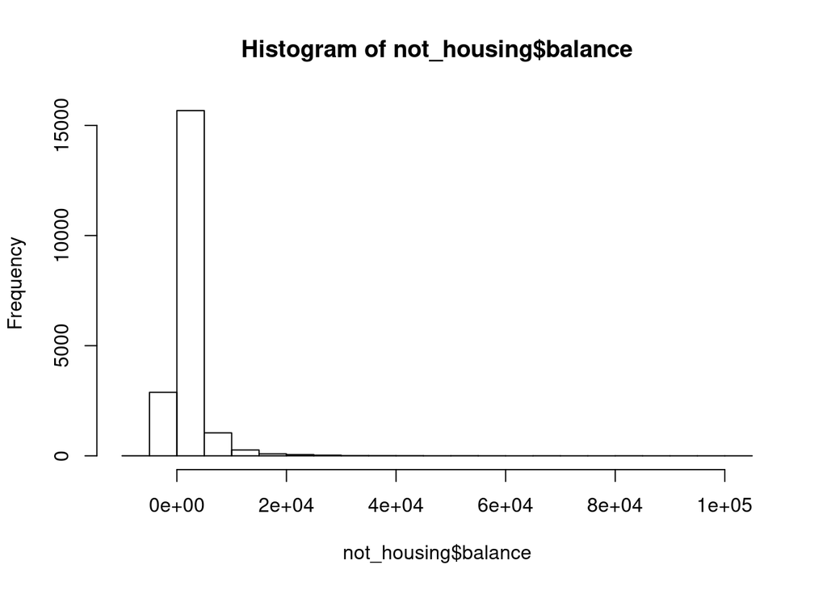

```r
hist(not_housing$balance)
```

```r
mean(not_housing$balance)
```

```
## [1] 1596.501
```

```r
median(not_housing$balance)
```

```
## [1] 507
```

Pelos dados acima, podemos ver que os clientes que possuem empréstimo imobiliário são um pouco mais novos que os que não possuem, mas a diferença é pequena.

A diferença no saldo médio da conta é um pouco mais pronunciada, com os clientes que não possuem empréstimos imobiliarios contando com maior saldo.

Quanto aos atributos categóricos:

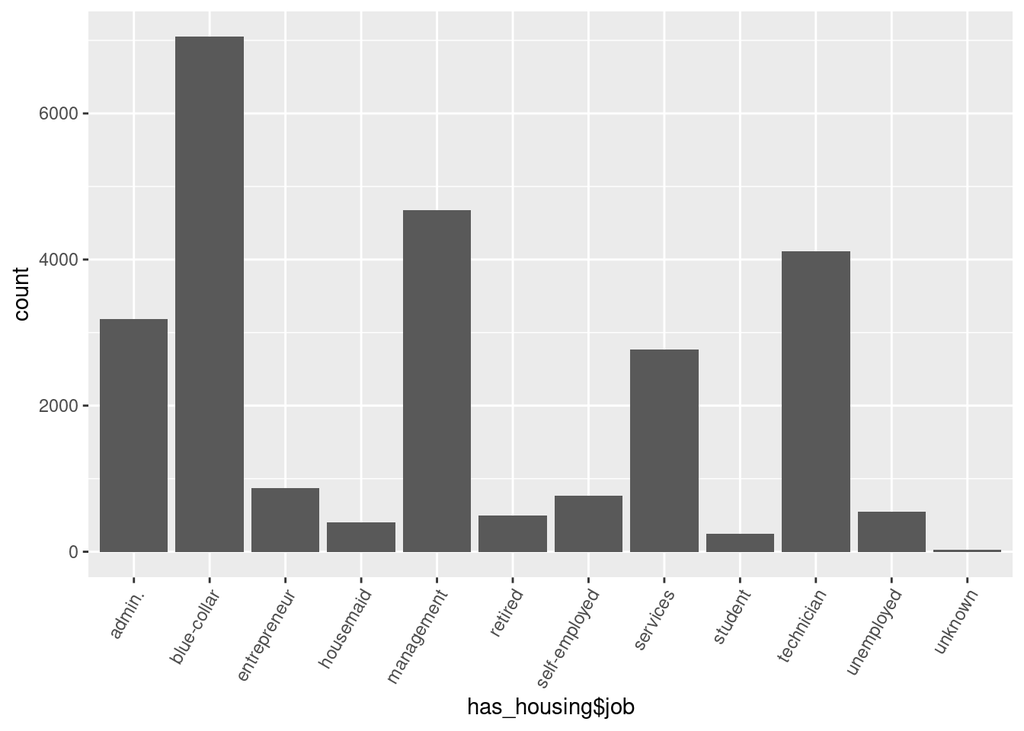

```r
ggplot(has_housing, aes(x=has_housing$job )) + geom_bar() +
    theme(axis.text.x = element_text(angle = 60, hjust = 1))
```

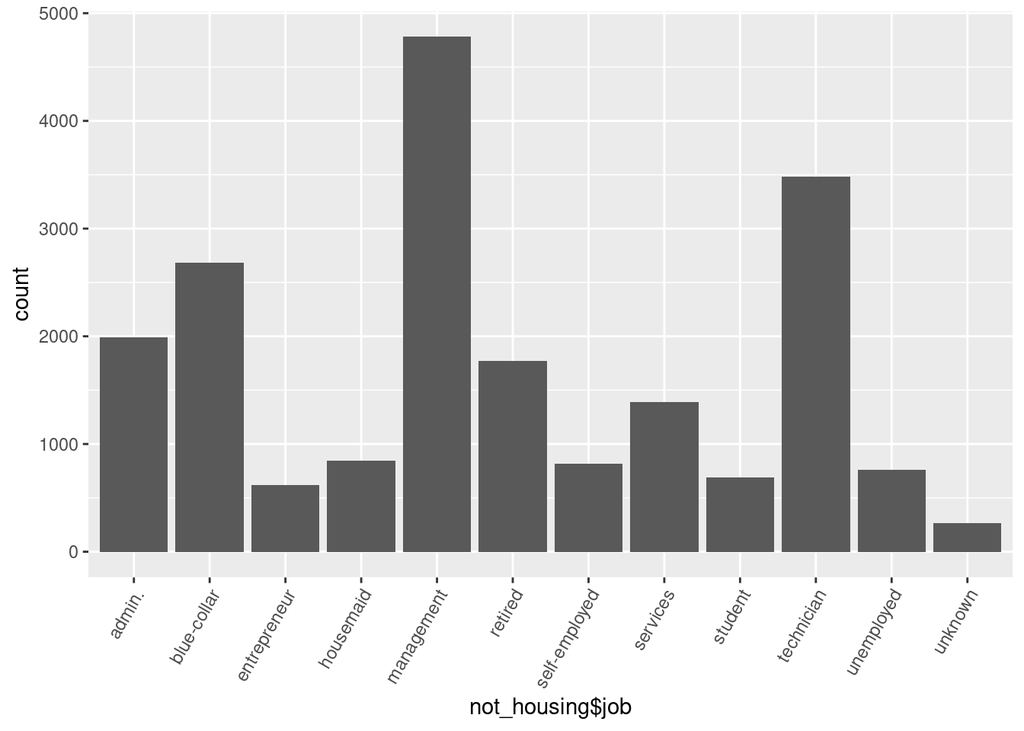

```r
ggplot(not_housing, aes(x=not_housing$job )) + geom_bar() +
    theme(axis.text.x = element_text(angle = 60, hjust = 1))
```

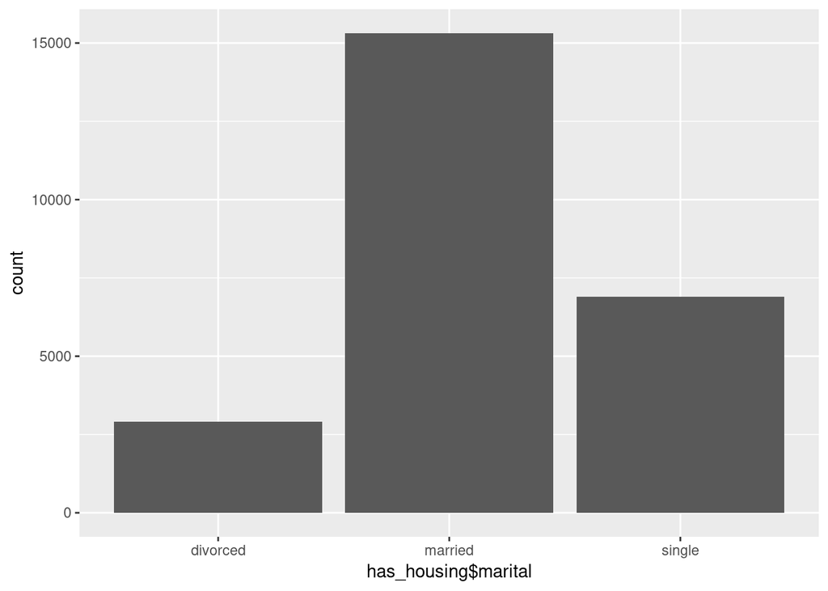

```r
ggplot(has_housing, aes(x=has_housing$marital )) + geom_bar()
```

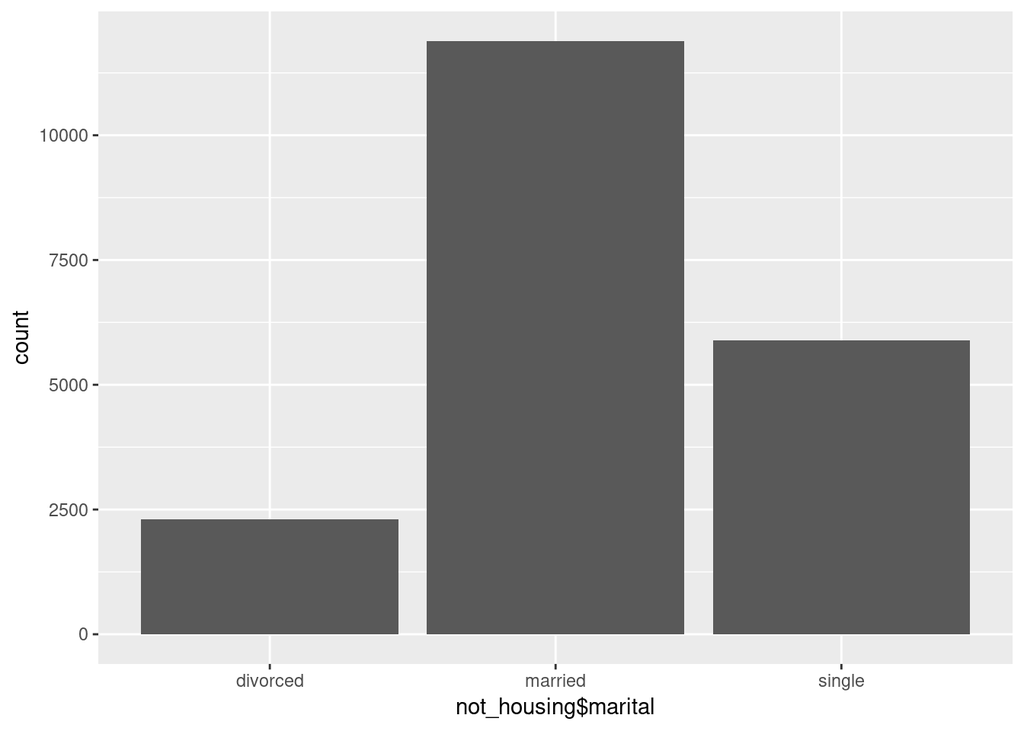

```r
ggplot(not_housing, aes(x=not_housing$marital )) + geom_bar()
```

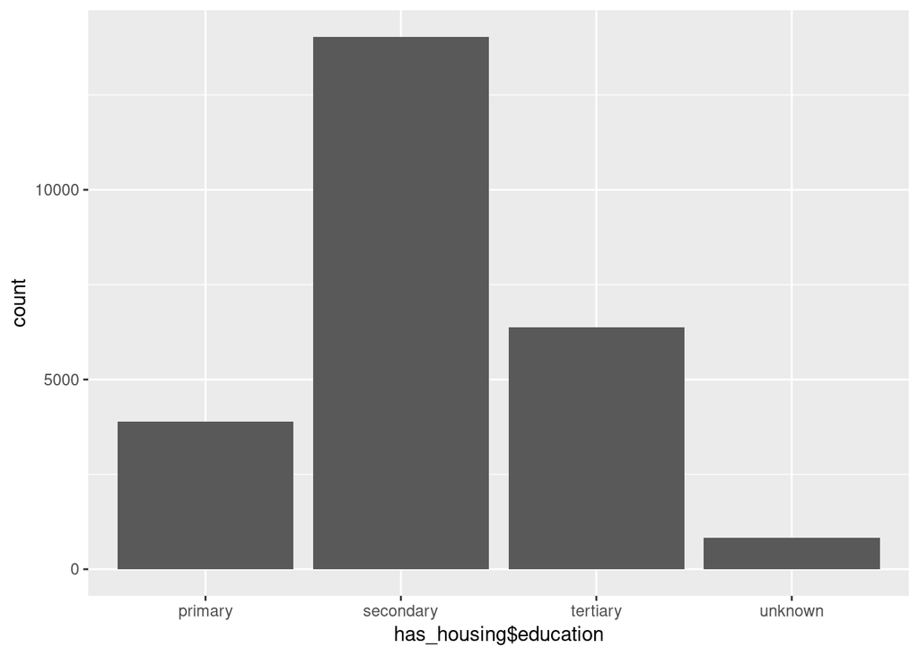

```r
ggplot(has_housing, aes(x=has_housing$education )) + geom_bar()
```

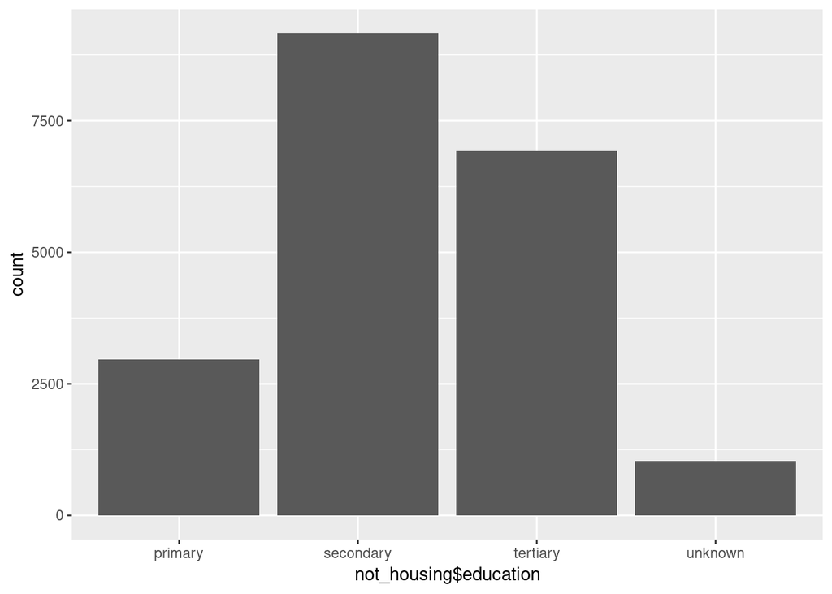

```r
ggplot(not_housing, aes(x=not_housing$education )) + geom_bar()
```

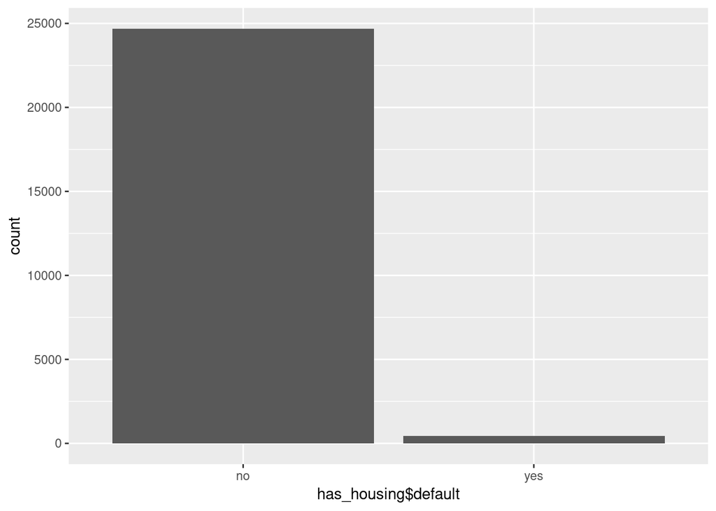

```r
ggplot(has_housing, aes(x=has_housing$default )) + geom_bar()
```

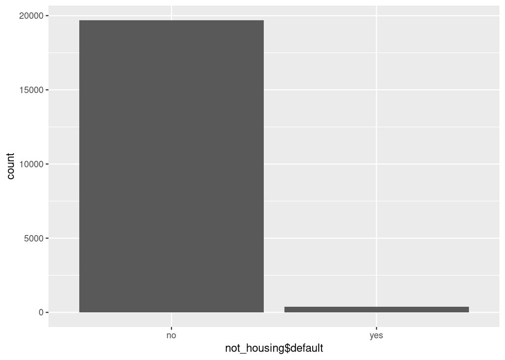

```r
ggplot(not_housing, aes(x=not_housing$default )) + geom_bar()
```

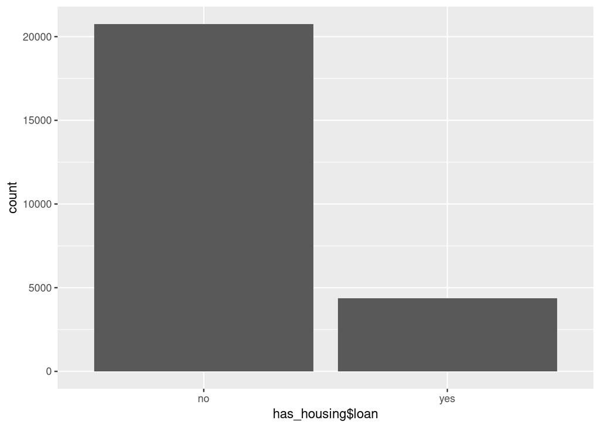

```r
ggplot(has_housing, aes(x=has_housing$loan )) + geom_bar()
```

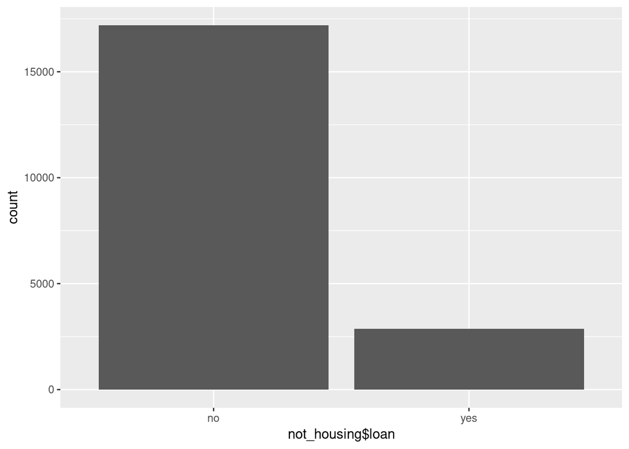

```r
ggplot(not_housing, aes(x=not_housing$loan )) + geom_bar()
```

Pelos dados acima, podemos notar que as variáveis loan, default e marital não apresentam comportamento distinto quando consideramos os dois grupos, mantendo-se aproximadamente as mesmas proporções.

A variável education apresenta uma diferença mais visível, a proporção de clientes com o terceiro grau (educação) é maior dentre os que não possuem um empréstimo imobiliário.

A diferença mais marcante, no entanto, encontra-se na comparação dos trabalhos dos dois grupos. Esse resultado já era parcialmente esperado, dado os resultados da questão 1 (e levando-se em consideração que os empréstimos imobiliários representam a maior parte do total de empréstimos). Pode-se perceber que as ocupações “management” e “retired” ocupam frações mais significativas do grupo dos que não possuem empréstimos imobiliários (em comparação com suas proporções no grupo dos que possuem empréstimos imobiliários), enquanto a ocupação “blue-collar” ocupa uma fração mais significativa do grupo que possue tais empréstimos.

Tomando um pouco de liberdade, poderíamos dizer que o cliente padrão que possui empréstimo imobiliário seria um trabalhador “blue-collar”, com por volta de 40 anos, casado, que estudou até o segundo grau e que não possui outros empréstimos.

## Referências

USING DATA MINING FOR BANK DIRECT MARKETING: AN APPLICATION OF THE CRISP-DM METHODOLOGY: http://hdl.handle.net/1822/14838

https://archive.ics.uci.edu/ml/datasets/Bank+Marketing